# Risk Factor Analysis

## Outcome Variable

**Outcome Variable:** ever_co

## Predictor Variables

**Intervention Variable:** exclfeed36

**Adjustment Set:**

- arm
- sex
- W_mage
- meducyrs
- feducyrs
- hhwealth_quart
- hfoodsec
- W_mhtcm
- vagbrth
- W_gagebrth
- W_birthwt
- W_birthlen
- W_nrooms
- W_nchldlt5
- month
- brthmon
- W_parity
- impfloor
- impsan
- safeh20
- delta_W_mage
- delta_meducyrs
- delta_feducyrs
- delta_hhwealth_quart
- delta_hfoodsec
- delta_W_mhtcm
- delta_vagbrth
- delta_W_gagebrth
- delta_W_birthwt
- delta_W_birthlen
- delta_W_nrooms
- delta_W_nchldlt5
- delta_month
- delta_brthmon
- delta_W_parity
- delta_impfloor
- delta_impsan
- delta_safeh20

## Stratifying Variables

The analysis was stratified on these variable(s):

- agecat
- studyid
- country

## Data Summary

| agecat | studyid | country | exclfeed36 | ever_co | n_cell | n |
| --- | --- | --- | --- | --- | --- | --- |
| 0-24 months | ki0047075b-MAL-ED | BANGLADESH | 1 | 0 | 51 | 251 |
| 0-24 months | ki0047075b-MAL-ED | BANGLADESH | 1 | 1 | 13 | 251 |
| 0-24 months | ki0047075b-MAL-ED | BANGLADESH | 0 | 0 | 161 | 251 |
| 0-24 months | ki0047075b-MAL-ED | BANGLADESH | 0 | 1 | 26 | 251 |
| 0-24 months | ki0047075b-MAL-ED | BRAZIL | 1 | 0 | 18 | 225 |
| 0-24 months | ki0047075b-MAL-ED | BRAZIL | 1 | 1 | 0 | 225 |
| 0-24 months | ki0047075b-MAL-ED | BRAZIL | 0 | 0 | 205 | 225 |
| 0-24 months | ki0047075b-MAL-ED | BRAZIL | 0 | 1 | 2 | 225 |
| 0-24 months | ki0047075b-MAL-ED | INDIA | 1 | 0 | 7 | 243 |
| 0-24 months | ki0047075b-MAL-ED | INDIA | 1 | 1 | 0 | 243 |
| 0-24 months | ki0047075b-MAL-ED | INDIA | 0 | 0 | 182 | 243 |
| 0-24 months | ki0047075b-MAL-ED | INDIA | 0 | 1 | 54 | 243 |
| 0-24 months | ki0047075b-MAL-ED | NEPAL | 1 | 0 | 14 | 238 |
| 0-24 months | ki0047075b-MAL-ED | NEPAL | 1 | 1 | 1 | 238 |
| 0-24 months | ki0047075b-MAL-ED | NEPAL | 0 | 0 | 203 | 238 |
| 0-24 months | ki0047075b-MAL-ED | NEPAL | 0 | 1 | 20 | 238 |
| 0-24 months | ki0047075b-MAL-ED | PERU | 1 | 0 | 16 | 287 |
| 0-24 months | ki0047075b-MAL-ED | PERU | 1 | 1 | 0 | 287 |
| 0-24 months | ki0047075b-MAL-ED | PERU | 0 | 0 | 260 | 287 |
| 0-24 months | ki0047075b-MAL-ED | PERU | 0 | 1 | 11 | 287 |
| 0-24 months | ki0047075b-MAL-ED | SOUTH AFRICA | 1 | 0 | 0 | 281 |
| 0-24 months | ki0047075b-MAL-ED | SOUTH AFRICA | 1 | 1 | 0 | 281 |
| 0-24 months | ki0047075b-MAL-ED | SOUTH AFRICA | 0 | 0 | 260 | 281 |
| 0-24 months | ki0047075b-MAL-ED | SOUTH AFRICA | 0 | 1 | 21 | 281 |
| 0-24 months | ki0047075b-MAL-ED | TANZANIA, UNITED REPUBLIC OF | 1 | 0 | 1 | 256 |
| 0-24 months | ki0047075b-MAL-ED | TANZANIA, UNITED REPUBLIC OF | 1 | 1 | 0 | 256 |
| 0-24 months | ki0047075b-MAL-ED | TANZANIA, UNITED REPUBLIC OF | 0 | 0 | 232 | 256 |
| 0-24 months | ki0047075b-MAL-ED | TANZANIA, UNITED REPUBLIC OF | 0 | 1 | 23 | 256 |
| 0-24 months | ki1000108-CMC-V-BCS-2002 | INDIA | 1 | 0 | 8 | 9 |
| 0-24 months | ki1000108-CMC-V-BCS-2002 | INDIA | 1 | 1 | 1 | 9 |

[output cut: 174 more lines]

The following strata were considered:

- agecat: 0-24 months, studyid: ki0047075b-MAL-ED, country: BANGLADESH
- agecat: 0-24 months, studyid: ki0047075b-MAL-ED, country: BRAZIL
- agecat: 0-24 months, studyid: ki0047075b-MAL-ED, country: INDIA
- agecat: 0-24 months, studyid: ki0047075b-MAL-ED, country: NEPAL
- agecat: 0-24 months, studyid: ki0047075b-MAL-ED, country: PERU
- agecat: 0-24 months, studyid: ki0047075b-MAL-ED, country: SOUTH AFRICA
- agecat: 0-24 months, studyid: ki0047075b-MAL-ED, country: TANZANIA, UNITED REPUBLIC OF
- agecat: 0-24 months, studyid: ki1000108-CMC-V-BCS-2002, country: INDIA
- agecat: 0-24 months, studyid: ki1000108-IRC, country: INDIA
- agecat: 0-24 months, studyid: ki1000109-EE, country: PAKISTAN
- agecat: 0-24 months, studyid: ki1000304b-SAS-FoodSuppl, country: INDIA
- agecat: 0-24 months, studyid: ki1017093b-PROVIDE, country: BANGLADESH
- agecat: 0-24 months, studyid: ki1101329-Keneba, country: GAMBIA
- agecat: 0-24 months, studyid: ki1113344-GMS-Nepal, country: NEPAL
- agecat: 0-24 months, studyid: ki1148112-LCNI-5, country: MALAWI
- agecat: 0-24 months, studyid: kiGH5241-JiVitA-3, country: BANGLADESH
- agecat: 0-24 months, studyid: kiGH5241-JiVitA-4, country: BANGLADESH
- agecat: 0-6 months, studyid: ki0047075b-MAL-ED, country: BANGLADESH
- agecat: 0-6 months, studyid: ki0047075b-MAL-ED, country: BRAZIL
- agecat: 0-6 months, studyid: ki0047075b-MAL-ED, country: INDIA
- agecat: 0-6 months, studyid: ki0047075b-MAL-ED, country: NEPAL
- agecat: 0-6 months, studyid: ki0047075b-MAL-ED, country: PERU
- agecat: 0-6 months, studyid: ki0047075b-MAL-ED, country: SOUTH AFRICA
- agecat: 0-6 months, studyid: ki0047075b-MAL-ED, country: TANZANIA, UNITED REPUBLIC OF
- agecat: 0-6 months, studyid: ki1000108-CMC-V-BCS-2002, country: INDIA
- agecat: 0-6 months, studyid: ki1000108-IRC, country: INDIA
- agecat: 0-6 months, studyid: ki1000109-EE, country: PAKISTAN
- agecat: 0-6 months, studyid: ki1000304b-SAS-FoodSuppl, country: INDIA
- agecat: 0-6 months, studyid: ki1017093b-PROVIDE, country: BANGLADESH
- agecat: 0-6 months, studyid: ki1101329-Keneba, country: GAMBIA
- agecat: 0-6 months, studyid: ki1113344-GMS-Nepal, country: NEPAL
- agecat: 0-6 months, studyid: ki1148112-LCNI-5, country: MALAWI
- agecat: 0-6 months, studyid: kiGH5241-JiVitA-3, country: BANGLADESH
- agecat: 0-6 months, studyid: kiGH5241-JiVitA-4, country: BANGLADESH
- agecat: 6-24 months, studyid: ki0047075b-MAL-ED, country: BANGLADESH
- agecat: 6-24 months, studyid: ki0047075b-MAL-ED, country: BRAZIL
- agecat: 6-24 months, studyid: ki0047075b-MAL-ED, country: INDIA
- agecat: 6-24 months, studyid: ki0047075b-MAL-ED, country: NEPAL
- agecat: 6-24 months, studyid: ki0047075b-MAL-ED, country: PERU
- agecat: 6-24 months, studyid: ki0047075b-MAL-ED, country: SOUTH AFRICA
- agecat: 6-24 months, studyid: ki0047075b-MAL-ED, country: TANZANIA, UNITED REPUBLIC OF
- agecat: 6-24 months, studyid: ki1000108-CMC-V-BCS-2002, country: INDIA
- agecat: 6-24 months, studyid: ki1000108-IRC, country: INDIA
- agecat: 6-24 months, studyid: ki1000109-EE, country: PAKISTAN
- agecat: 6-24 months, studyid: ki1000304b-SAS-FoodSuppl, country: INDIA
- agecat: 6-24 months, studyid: ki1017093b-PROVIDE, country: BANGLADESH
- agecat: 6-24 months, studyid: ki1101329-Keneba, country: GAMBIA
- agecat: 6-24 months, studyid: ki1113344-GMS-Nepal, country: NEPAL
- agecat: 6-24 months, studyid: ki1148112-LCNI-5, country: MALAWI
- agecat: 6-24 months, studyid: kiGH5241-JiVitA-3, country: BANGLADESH
- agecat: 6-24 months, studyid: kiGH5241-JiVitA-4, country: BANGLADESH

### Dropped Strata

Some strata were dropped due to rare outcomes:

- agecat: 0-24 months, studyid: ki0047075b-MAL-ED, country: BRAZIL
- agecat: 0-24 months, studyid: ki0047075b-MAL-ED, country: INDIA
- agecat: 0-24 months, studyid: ki0047075b-MAL-ED, country: NEPAL
- agecat: 0-24 months, studyid: ki0047075b-MAL-ED, country: PERU
- agecat: 0-24 months, studyid: ki0047075b-MAL-ED, country: SOUTH AFRICA
- agecat: 0-24 months, studyid: ki0047075b-MAL-ED, country: TANZANIA, UNITED REPUBLIC OF
- agecat: 0-24 months, studyid: ki1000108-CMC-V-BCS-2002, country: INDIA
- agecat: 0-24 months, studyid: ki1000108-IRC, country: INDIA
- agecat: 0-24 months, studyid: ki1000304b-SAS-FoodSuppl, country: INDIA
- agecat: 0-24 months, studyid: ki1148112-LCNI-5, country: MALAWI
- agecat: 0-6 months, studyid: ki0047075b-MAL-ED, country: BANGLADESH
- agecat: 0-6 months, studyid: ki0047075b-MAL-ED, country: BRAZIL
- agecat: 0-6 months, studyid: ki0047075b-MAL-ED, country: INDIA
- agecat: 0-6 months, studyid: ki0047075b-MAL-ED, country: NEPAL
- agecat: 0-6 months, studyid: ki0047075b-MAL-ED, country: PERU
- agecat: 0-6 months, studyid: ki0047075b-MAL-ED, country: SOUTH AFRICA
- agecat: 0-6 months, studyid: ki0047075b-MAL-ED, country: TANZANIA, UNITED REPUBLIC OF
- agecat: 0-6 months, studyid: ki1000108-CMC-V-BCS-2002, country: INDIA
- agecat: 0-6 months, studyid: ki1000108-IRC, country: INDIA
- agecat: 0-6 months, studyid: ki1000304b-SAS-FoodSuppl, country: INDIA
- agecat: 0-6 months, studyid: ki1017093b-PROVIDE, country: BANGLADESH
- agecat: 0-6 months, studyid: ki1148112-LCNI-5, country: MALAWI
- agecat: 6-24 months, studyid: ki0047075b-MAL-ED, country: BRAZIL
- agecat: 6-24 months, studyid: ki0047075b-MAL-ED, country: INDIA
- agecat: 6-24 months, studyid: ki0047075b-MAL-ED, country: NEPAL
- agecat: 6-24 months, studyid: ki0047075b-MAL-ED, country: PERU
- agecat: 6-24 months, studyid: ki0047075b-MAL-ED, country: SOUTH AFRICA
- agecat: 6-24 months, studyid: ki0047075b-MAL-ED, country: TANZANIA, UNITED REPUBLIC OF
- agecat: 6-24 months, studyid: ki1000108-CMC-V-BCS-2002, country: INDIA
- agecat: 6-24 months, studyid: ki1000108-IRC, country: INDIA
- agecat: 6-24 months, studyid: ki1000304b-SAS-FoodSuppl, country: INDIA
- agecat: 6-24 months, studyid: ki1148112-LCNI-5, country: MALAWI

## Methods Detail

We’re interested in the causal parameters $E[Y_a]$ for all values of $a \in \mathcal{A}$. These parameters represent the mean outcome if, possibly contrary to fact, we intervened to set all units to have $A=a$. Under the randomization and positivity assumptions, these are identified by the statistical parameters $\psi_a=E_W[E_{Y|A,W}(Y|A=a,W)]$. In addition, we’re interested in the mean of $Y$, $E[Y]$ under no intervention (the observed mean). We will estimate these parameters by using SuperLearner to fit the relevant likelihood factors – $E_{Y|A,W}(Y|A=a,W)$ and $p(A=a|W)$, and then updating our likelihood fit using a joint TMLE.

For unadjusted analyses ($W=\{\}$), initial likelihoods were estimated using Lrnr_glm to estimate the simple $E(Y|A)$ and Lrnr_mean to estimate $p(A)$. For adjusted analyses, a small library containing Lrnr_glmnet, Lrnr_xgboost, and Lrnr_mean was used.

Having estimated these parameters, we will then use the delta method to estimate relative risks and attributable risks relative to a prespecified baseline level of $A$.

# Results Detail

## Results Plots

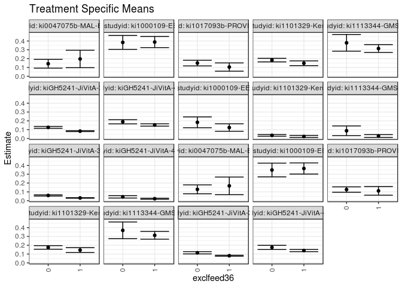

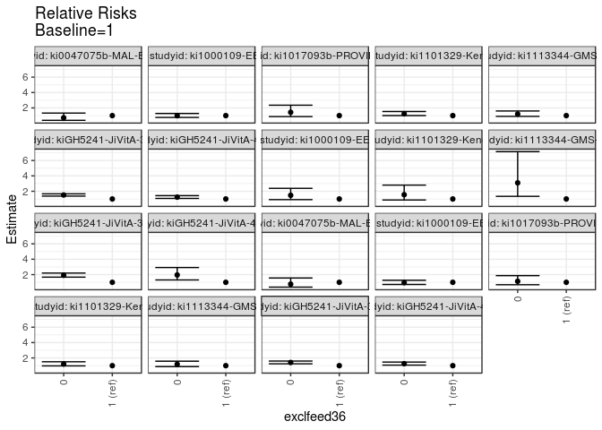

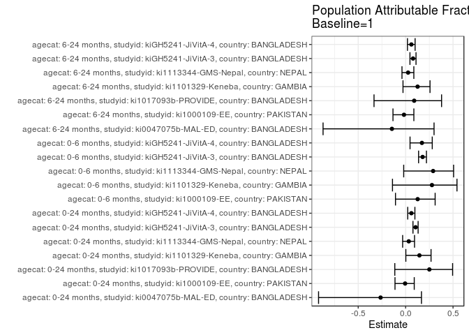

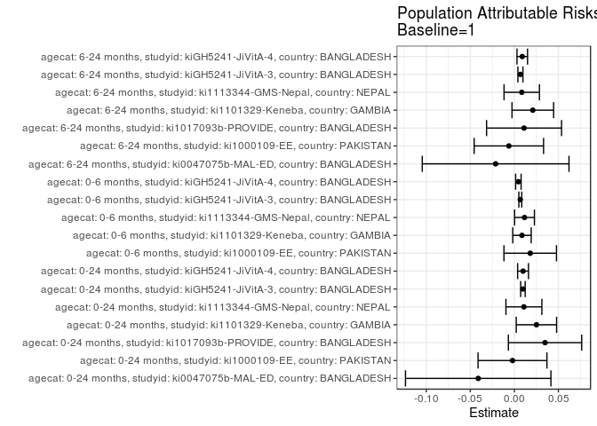

## Results Table

### Parameter: TSM

| agecat | studyid | country | intervention_level | baseline_level | estimate | ci_lower | ci_upper |
| --- | --- | --- | --- | --- | --- | --- | --- |
| 0-24 months | ki0047075b-MAL-ED | BANGLADESH | 1 | NA | 0.1963924 | 0.0975749 | 0.2952099 |
| 0-24 months | ki0047075b-MAL-ED | BANGLADESH | 0 | NA | 0.1417617 | 0.0920963 | 0.1914270 |
| 0-24 months | ki1000109-EE | PAKISTAN | 1 | NA | 0.3881552 | 0.3250474 | 0.4512629 |
| 0-24 months | ki1000109-EE | PAKISTAN | 0 | NA | 0.3838238 | 0.3050447 | 0.4626029 |
| 0-24 months | ki1017093b-PROVIDE | BANGLADESH | 1 | NA | 0.1044159 | 0.0576071 | 0.1512246 |
| 0-24 months | ki1017093b-PROVIDE | BANGLADESH | 0 | NA | 0.1497120 | 0.1174068 | 0.1820171 |
| 0-24 months | ki1101329-Keneba | GAMBIA | 1 | NA | 0.1473811 | 0.1202928 | 0.1744695 |
| 0-24 months | ki1101329-Keneba | GAMBIA | 0 | NA | 0.1832084 | 0.1628622 | 0.2035546 |
| 0-24 months | ki1113344-GMS-Nepal | NEPAL | 1 | NA | 0.3149006 | 0.2707875 | 0.3590136 |
| 0-24 months | ki1113344-GMS-Nepal | NEPAL | 0 | NA | 0.3790645 | 0.2845531 | 0.4735759 |
| 0-24 months | kiGH5241-JiVitA-3 | BANGLADESH | 1 | NA | 0.0830582 | 0.0782712 | 0.0878451 |
| 0-24 months | kiGH5241-JiVitA-3 | BANGLADESH | 0 | NA | 0.1257667 | 0.1153967 | 0.1361367 |
| 0-24 months | kiGH5241-JiVitA-4 | BANGLADESH | 1 | NA | 0.1531103 | 0.1397761 | 0.1664444 |
| 0-24 months | kiGH5241-JiVitA-4 | BANGLADESH | 0 | NA | 0.1892705 | 0.1654622 | 0.2130789 |
| 0-6 months | ki1000109-EE | PAKISTAN | 1 | NA | 0.1240552 | 0.0815709 | 0.1665396 |
| 0-6 months | ki1000109-EE | PAKISTAN | 0 | NA | 0.1830400 | 0.1216570 | 0.2444229 |
| 0-6 months | ki1101329-Keneba | GAMBIA | 1 | NA | 0.0225878 | 0.0109108 | 0.0342647 |
| 0-6 months | ki1101329-Keneba | GAMBIA | 0 | NA | 0.0351698 | 0.0253786 | 0.0449611 |
| 0-6 months | ki1113344-GMS-Nepal | NEPAL | 1 | NA | 0.0282353 | 0.0124722 | 0.0439984 |
| 0-6 months | ki1113344-GMS-Nepal | NEPAL | 0 | NA | 0.0873786 | 0.0327917 | 0.1419656 |
| 0-6 months | kiGH5241-JiVitA-3 | BANGLADESH | 1 | NA | 0.0309763 | 0.0281844 | 0.0337682 |
| 0-6 months | kiGH5241-JiVitA-3 | BANGLADESH | 0 | NA | 0.0593245 | 0.0524009 | 0.0662482 |
| 0-6 months | kiGH5241-JiVitA-4 | BANGLADESH | 1 | NA | 0.0220452 | 0.0161340 | 0.0279564 |
| 0-6 months | kiGH5241-JiVitA-4 | BANGLADESH | 0 | NA | 0.0431032 | 0.0297789 | 0.0564275 |
| 6-24 months | ki0047075b-MAL-ED | BANGLADESH | 1 | NA | 0.1683028 | 0.0684518 | 0.2681539 |
| 6-24 months | ki0047075b-MAL-ED | BANGLADESH | 0 | NA | 0.1283683 | 0.0779021 | 0.1788346 |
| 6-24 months | ki1000109-EE | PAKISTAN | 1 | NA | 0.3649073 | 0.3017872 | 0.4280274 |
| 6-24 months | ki1000109-EE | PAKISTAN | 0 | NA | 0.3478966 | 0.2700520 | 0.4257412 |
| 6-24 months | ki1017093b-PROVIDE | BANGLADESH | 1 | NA | 0.1113184 | 0.0623934 | 0.1602434 |
| 6-24 months | ki1017093b-PROVIDE | BANGLADESH | 0 | NA | 0.1261510 | 0.0955717 | 0.1567303 |
| 6-24 months | ki1101329-Keneba | GAMBIA | 1 | NA | 0.1450070 | 0.1172577 | 0.1727563 |
| 6-24 months | ki1101329-Keneba | GAMBIA | 0 | NA | 0.1750427 | 0.1547224 | 0.1953631 |
| 6-24 months | ki1113344-GMS-Nepal | NEPAL | 1 | NA | 0.3128906 | 0.2688500 | 0.3569312 |
| 6-24 months | ki1113344-GMS-Nepal | NEPAL | 0 | NA | 0.3690255 | 0.2743883 | 0.4636627 |
| 6-24 months | kiGH5241-JiVitA-3 | BANGLADESH | 1 | NA | 0.0812518 | 0.0757627 | 0.0867409 |
| 6-24 months | kiGH5241-JiVitA-3 | BANGLADESH | 0 | NA | 0.1145252 | 0.1018437 | 0.1272067 |
| 6-24 months | kiGH5241-JiVitA-4 | BANGLADESH | 1 | NA | 0.1396732 | 0.1271467 | 0.1521996 |
| 6-24 months | kiGH5241-JiVitA-4 | BANGLADESH | 0 | NA | 0.1752826 | 0.1517161 | 0.1988490 |

### Parameter: E(Y)

| agecat | studyid | country | intervention_level | baseline_level | estimate | ci_lower | ci_upper |
| --- | --- | --- | --- | --- | --- | --- | --- |
| 0-24 months | ki0047075b-MAL-ED | BANGLADESH | NA | NA | 0.1553785 | 0.1104725 | 0.2002845 |
| 0-24 months | ki1000109-EE | PAKISTAN | NA | NA | 0.3860590 | 0.3365861 | 0.4355318 |
| 0-24 months | ki1017093b-PROVIDE | BANGLADESH | NA | NA | 0.1392801 | 0.1124135 | 0.1661468 |
| 0-24 months | ki1101329-Keneba | GAMBIA | NA | NA | 0.1724660 | 0.1558341 | 0.1890978 |
| 0-24 months | ki1113344-GMS-Nepal | NEPAL | NA | NA | 0.3257576 | 0.2857449 | 0.3657703 |
| 0-24 months | kiGH5241-JiVitA-3 | BANGLADESH | NA | NA | 0.0928037 | 0.0883057 | 0.0973017 |
| 0-24 months | kiGH5241-JiVitA-4 | BANGLADESH | NA | NA | 0.1630101 | 0.1508647 | 0.1751555 |
| 0-6 months | ki1000109-EE | PAKISTAN | NA | NA | 0.1420912 | 0.1066114 | 0.1775709 |
| 0-6 months | ki1101329-Keneba | GAMBIA | NA | NA | 0.0312658 | 0.0236039 | 0.0389276 |
| 0-6 months | ki1113344-GMS-Nepal | NEPAL | NA | NA | 0.0397727 | 0.0230879 | 0.0564576 |
| 0-6 months | kiGH5241-JiVitA-3 | BANGLADESH | NA | NA | 0.0377388 | 0.0349183 | 0.0405593 |
| 0-6 months | kiGH5241-JiVitA-4 | BANGLADESH | NA | NA | 0.0266227 | 0.0211044 | 0.0321409 |
| 6-24 months | ki0047075b-MAL-ED | BANGLADESH | NA | NA | 0.1470588 | 0.1019690 | 0.1921487 |
| 6-24 months | ki1000109-EE | PAKISTAN | NA | NA | 0.3586957 | 0.3096263 | 0.4077650 |
| 6-24 months | ki1017093b-PROVIDE | BANGLADESH | NA | NA | 0.1223491 | 0.0963874 | 0.1483108 |
| 6-24 months | ki1101329-Keneba | GAMBIA | NA | NA | 0.1659664 | 0.1492505 | 0.1826823 |
| 6-24 months | ki1113344-GMS-Nepal | NEPAL | NA | NA | 0.3212928 | 0.2813480 | 0.3612376 |
| 6-24 months | kiGH5241-JiVitA-3 | BANGLADESH | NA | NA | 0.0881474 | 0.0829797 | 0.0933152 |
| 6-24 months | kiGH5241-JiVitA-4 | BANGLADESH | NA | NA | 0.1486695 | 0.1373410 | 0.1599979 |

### Parameter: RR

| agecat | studyid | country | intervention_level | baseline_level | estimate | ci_lower | ci_upper |
| --- | --- | --- | --- | --- | --- | --- | --- |
| 0-24 months | ki0047075b-MAL-ED | BANGLADESH | 1 | 1 | 1.0000000 | 1.0000000 | 1.000000 |
| 0-24 months | ki0047075b-MAL-ED | BANGLADESH | 0 | 1 | 0.7218287 | 0.3917140 | 1.330146 |
| 0-24 months | ki1000109-EE | PAKISTAN | 1 | 1 | 1.0000000 | 1.0000000 | 1.000000 |
| 0-24 months | ki1000109-EE | PAKISTAN | 0 | 1 | 0.9888411 | 0.7639967 | 1.279857 |
| 0-24 months | ki1017093b-PROVIDE | BANGLADESH | 1 | 1 | 1.0000000 | 1.0000000 | 1.000000 |
| 0-24 months | ki1017093b-PROVIDE | BANGLADESH | 0 | 1 | 1.4338049 | 0.8725506 | 2.356077 |
| 0-24 months | ki1101329-Keneba | GAMBIA | 1 | 1 | 1.0000000 | 1.0000000 | 1.000000 |
| 0-24 months | ki1101329-Keneba | GAMBIA | 0 | 1 | 1.2430924 | 1.0062831 | 1.535630 |
| 0-24 months | ki1113344-GMS-Nepal | NEPAL | 1 | 1 | 1.0000000 | 1.0000000 | 1.000000 |
| 0-24 months | ki1113344-GMS-Nepal | NEPAL | 0 | 1 | 1.2037594 | 0.9044327 | 1.602150 |
| 0-24 months | kiGH5241-JiVitA-3 | BANGLADESH | 1 | 1 | 1.0000000 | 1.0000000 | 1.000000 |
| 0-24 months | kiGH5241-JiVitA-3 | BANGLADESH | 0 | 1 | 1.5142005 | 1.3736600 | 1.669120 |
| 0-24 months | kiGH5241-JiVitA-4 | BANGLADESH | 1 | 1 | 1.0000000 | 1.0000000 | 1.000000 |
| 0-24 months | kiGH5241-JiVitA-4 | BANGLADESH | 0 | 1 | 1.2361714 | 1.0681105 | 1.430676 |
| 0-6 months | ki1000109-EE | PAKISTAN | 1 | 1 | 1.0000000 | 1.0000000 | 1.000000 |
| 0-6 months | ki1000109-EE | PAKISTAN | 0 | 1 | 1.4754717 | 0.9142040 | 2.381325 |
| 0-6 months | ki1101329-Keneba | GAMBIA | 1 | 1 | 1.0000000 | 1.0000000 | 1.000000 |
| 0-6 months | ki1101329-Keneba | GAMBIA | 0 | 1 | 1.5570304 | 0.8651906 | 2.802092 |
| 0-6 months | ki1113344-GMS-Nepal | NEPAL | 1 | 1 | 1.0000000 | 1.0000000 | 1.000000 |
| 0-6 months | ki1113344-GMS-Nepal | NEPAL | 0 | 1 | 3.0946602 | 1.3389106 | 7.152771 |
| 0-6 months | kiGH5241-JiVitA-3 | BANGLADESH | 1 | 1 | 1.0000000 | 1.0000000 | 1.000000 |
| 0-6 months | kiGH5241-JiVitA-3 | BANGLADESH | 0 | 1 | 1.9151595 | 1.6691414 | 2.197439 |
| 0-6 months | kiGH5241-JiVitA-4 | BANGLADESH | 1 | 1 | 1.0000000 | 1.0000000 | 1.000000 |
| 0-6 months | kiGH5241-JiVitA-4 | BANGLADESH | 0 | 1 | 1.9552200 | 1.3077023 | 2.923360 |
| 6-24 months | ki0047075b-MAL-ED | BANGLADESH | 1 | 1 | 1.0000000 | 1.0000000 | 1.000000 |
| 6-24 months | ki0047075b-MAL-ED | BANGLADESH | 0 | 1 | 0.7627224 | 0.3732412 | 1.558631 |
| 6-24 months | ki1000109-EE | PAKISTAN | 1 | 1 | 1.0000000 | 1.0000000 | 1.000000 |
| 6-24 months | ki1000109-EE | PAKISTAN | 0 | 1 | 0.9533837 | 0.7196445 | 1.263041 |
| 6-24 months | ki1017093b-PROVIDE | BANGLADESH | 1 | 1 | 1.0000000 | 1.0000000 | 1.000000 |
| 6-24 months | ki1017093b-PROVIDE | BANGLADESH | 0 | 1 | 1.1332445 | 0.6868053 | 1.869879 |
| 6-24 months | ki1101329-Keneba | GAMBIA | 1 | 1 | 1.0000000 | 1.0000000 | 1.000000 |
| 6-24 months | ki1101329-Keneba | GAMBIA | 0 | 1 | 1.2071334 | 0.9680603 | 1.505248 |
| 6-24 months | ki1113344-GMS-Nepal | NEPAL | 1 | 1 | 1.0000000 | 1.0000000 | 1.000000 |
| 6-24 months | ki1113344-GMS-Nepal | NEPAL | 0 | 1 | 1.1794075 | 0.8802905 | 1.580163 |
| 6-24 months | kiGH5241-JiVitA-3 | BANGLADESH | 1 | 1 | 1.0000000 | 1.0000000 | 1.000000 |
| 6-24 months | kiGH5241-JiVitA-3 | BANGLADESH | 0 | 1 | 1.4095108 | 1.2421348 | 1.599441 |
| 6-24 months | kiGH5241-JiVitA-4 | BANGLADESH | 1 | 1 | 1.0000000 | 1.0000000 | 1.000000 |
| 6-24 months | kiGH5241-JiVitA-4 | BANGLADESH | 0 | 1 | 1.2549482 | 1.0719566 | 1.469178 |

### Parameter: PAR

| agecat | studyid | country | intervention_level | baseline_level | estimate | ci_lower | ci_upper |
| --- | --- | --- | --- | --- | --- | --- | --- |
| 0-24 months | ki0047075b-MAL-ED | BANGLADESH | 1 | NA | -0.0410139 | -0.1235610 | 0.0415333 |
| 0-24 months | ki1000109-EE | PAKISTAN | 1 | NA | -0.0020962 | -0.0412082 | 0.0370158 |
| 0-24 months | ki1017093b-PROVIDE | BANGLADESH | 1 | NA | 0.0348643 | -0.0067521 | 0.0764807 |
| 0-24 months | ki1101329-Keneba | GAMBIA | 1 | NA | 0.0250848 | 0.0021734 | 0.0479962 |
| 0-24 months | ki1113344-GMS-Nepal | NEPAL | 1 | NA | 0.0108570 | -0.0095473 | 0.0312613 |
| 0-24 months | kiGH5241-JiVitA-3 | BANGLADESH | 1 | NA | 0.0097456 | 0.0071863 | 0.0123048 |
| 0-24 months | kiGH5241-JiVitA-4 | BANGLADESH | 1 | NA | 0.0098998 | 0.0037399 | 0.0160597 |
| 0-6 months | ki1000109-EE | PAKISTAN | 1 | NA | 0.0180359 | -0.0117843 | 0.0478562 |
| 0-6 months | ki1101329-Keneba | GAMBIA | 1 | NA | 0.0086780 | -0.0018103 | 0.0191663 |
| 0-6 months | ki1113344-GMS-Nepal | NEPAL | 1 | NA | 0.0115374 | 0.0002746 | 0.0228003 |
| 0-6 months | kiGH5241-JiVitA-3 | BANGLADESH | 1 | NA | 0.0067625 | 0.0051208 | 0.0084041 |
| 0-6 months | kiGH5241-JiVitA-4 | BANGLADESH | 1 | NA | 0.0045775 | 0.0014727 | 0.0076822 |
| 6-24 months | ki0047075b-MAL-ED | BANGLADESH | 1 | NA | -0.0212440 | -0.1045414 | 0.0620534 |
| 6-24 months | ki1000109-EE | PAKISTAN | 1 | NA | -0.0062116 | -0.0456153 | 0.0331920 |
| 6-24 months | ki1017093b-PROVIDE | BANGLADESH | 1 | NA | 0.0110307 | -0.0315341 | 0.0535955 |
| 6-24 months | ki1101329-Keneba | GAMBIA | 1 | NA | 0.0209594 | -0.0026546 | 0.0445735 |
| 6-24 months | ki1113344-GMS-Nepal | NEPAL | 1 | NA | 0.0084022 | -0.0116853 | 0.0284897 |
| 6-24 months | kiGH5241-JiVitA-3 | BANGLADESH | 1 | NA | 0.0068957 | 0.0040403 | 0.0097511 |
| 6-24 months | kiGH5241-JiVitA-4 | BANGLADESH | 1 | NA | 0.0089963 | 0.0030011 | 0.0149915 |

### Parameter: PAF

| agecat | studyid | country | intervention_level | baseline_level | estimate | ci_lower | ci_upper |
| --- | --- | --- | --- | --- | --- | --- | --- |
| 0-24 months | ki0047075b-MAL-ED | BANGLADESH | 1 | NA | -0.2639611 | -0.9179985 | 0.1670496 |
| 0-24 months | ki1000109-EE | PAKISTAN | 1 | NA | -0.0054297 | -0.1120224 | 0.0909455 |
| 0-24 months | ki1017093b-PROVIDE | BANGLADESH | 1 | NA | 0.2503176 | -0.1141473 | 0.4955572 |
| 0-24 months | ki1101329-Keneba | GAMBIA | 1 | NA | 0.1454479 | 0.0023124 | 0.2680482 |
| 0-24 months | ki1113344-GMS-Nepal | NEPAL | 1 | NA | 0.0333285 | -0.0313335 | 0.0939364 |
| 0-24 months | kiGH5241-JiVitA-3 | BANGLADESH | 1 | NA | 0.1050127 | 0.0774061 | 0.1317932 |
| 0-24 months | kiGH5241-JiVitA-4 | BANGLADESH | 1 | NA | 0.0607313 | 0.0221315 | 0.0978075 |
| 0-6 months | ki1000109-EE | PAKISTAN | 1 | NA | 0.1269321 | -0.1067972 | 0.3113033 |
| 0-6 months | ki1101329-Keneba | GAMBIA | 1 | NA | 0.2775558 | -0.1385029 | 0.5415685 |
| 0-6 months | ki1113344-GMS-Nepal | NEPAL | 1 | NA | 0.2900840 | -0.0201657 | 0.5059815 |
| 0-6 months | kiGH5241-JiVitA-3 | BANGLADESH | 1 | NA | 0.1791918 | 0.1367495 | 0.2195473 |
| 0-6 months | kiGH5241-JiVitA-4 | BANGLADESH | 1 | NA | 0.1719384 | 0.0466004 | 0.2807988 |
| 6-24 months | ki0047075b-MAL-ED | BANGLADESH | 1 | NA | -0.1444593 | -0.8705120 | 0.2997708 |
| 6-24 months | ki1000109-EE | PAKISTAN | 1 | NA | -0.0173173 | -0.1333326 | 0.0868219 |
| 6-24 months | ki1017093b-PROVIDE | BANGLADESH | 1 | NA | 0.0901575 | -0.3332075 | 0.3790814 |
| 6-24 months | ki1101329-Keneba | GAMBIA | 1 | NA | 0.1262872 | -0.0276327 | 0.2571527 |
| 6-24 months | ki1113344-GMS-Nepal | NEPAL | 1 | NA | 0.0261512 | -0.0383818 | 0.0866736 |
| 6-24 months | kiGH5241-JiVitA-3 | BANGLADESH | 1 | NA | 0.0782290 | 0.0456867 | 0.1096617 |
| 6-24 months | kiGH5241-JiVitA-4 | BANGLADESH | 1 | NA | 0.0605120 | 0.0192941 | 0.0999976 |